# NYC Schools

Aaron Wright

29/03/2021

## Introduction

In this project we want to assess whether student, teacher, and parent perceptions of NYC school quality appear to be related to demographic and academic success metrics. We also want to assess whether they all have similar perceptions of NYC school quality.

The project also servers the purpose of devloping my data cleaning skills in R.

The data has been downloaded from the following locations:

- https://data.world/dataquest/nyc-schools-data/workspace/file?filename=combined.csv
- https://data.cityofnewyork.us/Education/2011-NYC-School-Survey/mnz3-dyi8

We have loaded the tidyverse and corrplot packages for this exercise. To import the **combined** data, we use `read_csv`. This is data we cleaned in a previous exericse which will be of use here. For the **general schools** data and **district 75 schools** data, we ue `read_tsv`.

From reading the `data dictionary` we can see that there is a `DBN` column, which we’ll use as a key when combining datasets.

```r
# Load in combined data on schools
combined <- read_csv("combined.csv", col_types = cols())

# Load in survey data for general schools
general <- read_tsv("masterfile11_gened_final.txt", col_types = cols())

# Load in survey data for District 75 schools
district_75 <- read_tsv("masterfile11_d75_final.txt", col_types = cols())
```

## Exploring Data

```r
# Combined data
glimpse(combined)
```

```
## Rows: 479
## Columns: 30
## $ DBN                                    <chr> "01M292", "01M448", "01M450", "…
## $ school_name                            <chr> "HENRY STREET SCHOOL FOR INTERN…
## $ `Num of SAT Test Takers`               <dbl> 29, 91, 70, 7, 44, 112, 159, 18…
## $ `SAT Critical Reading Avg. Score`      <dbl> 355, 383, 377, 414, 390, 332, 5…
## $ `SAT Math Avg. Score`                  <dbl> 404, 423, 402, 401, 433, 557, 5…
## $ `SAT Writing Avg. Score`               <dbl> 363, 366, 370, 359, 384, 316, 5…
## $ avg_sat_score                          <dbl> 1122, 1172, 1149, 1174, 1207, 1…
## $ `AP Test Takers`                       <dbl> 2.5, 39.0, 19.0, 2.5, 2.5, 24.0…
## $ `Total Exams Taken`                    <dbl> NA, 49, 21, NA, NA, 26, 377, NA…
## $ `Number of Exams with scores 3 4 or 5` <dbl> NA, 10, NA, NA, NA, 24, 191, NA…
## $ exams_per_student                      <dbl> NA, 1.256410, 1.105263, NA, NA,…
## $ high_score_percent                     <dbl> NA, 20.408163, NA, NA, NA, 92.3…
## $ avg_class_size                         <dbl> 23, 22, 21, 23, 24, 23, 26, 22,…
```

[output cut: 17 more lines]

```r
# General Data
head(general)
```

```
## # A tibble: 6 x 1,942
##   dbn    bn    schoolname     d75 studentssurveyed highschool schooltype    rr_s
##   <chr>  <chr> <chr>        <dbl> <chr>                 <dbl> <chr>        <dbl>
## 1 01M015 M015  P.S. 015 Ro…     0 No                        0 Elementary …    NA
## 2 01M019 M019  P.S. 019 As…     0 No                        0 Elementary …    NA
## 3 01M020 M020  P.S. 020 An…     0 No                        0 Elementary …    NA
## 4 01M034 M034  P.S. 034 Fr…     0 Yes                       0 Elementary …    89
## 5 01M063 M063  P.S. 063 Wi…     0 No                        0 Elementary …    NA
## 6 01M064 M064  P.S. 064 Ro…     0 No                        0 Elementary …    NA
## # … with 1,934 more variables: rr_t <dbl>, rr_p <dbl>, N_s <dbl>, N_t <dbl>,
## #   N_p <dbl>, nr_s <dbl>, nr_t <dbl>, nr_p <dbl>, saf_p_11 <dbl>,
## #   com_p_11 <dbl>, eng_p_11 <dbl>, aca_p_11 <dbl>, saf_t_11 <dbl>,
## #   com_t_11 <dbl>, eng_t_11 <dbl>, aca_t_11 <dbl>, saf_s_11 <dbl>,
## #   com_s_11 <dbl>, eng_s_11 <dbl>, aca_s_11 <dbl>, saf_tot_11 <dbl>,
## #   com_tot_11 <dbl>, eng_tot_11 <dbl>, aca_tot_11 <dbl>, p_q2h <dbl>,
## #   p_q7a <dbl>, p_q7b <dbl>, p_q7c <dbl>, p_q7d <dbl>, p_q8a <dbl>,
## #   p_q8b <dbl>, p_q8c <dbl>, p_q8d <dbl>, p_q8e <dbl>, p_q8f <dbl>,
## #   p_q2b <dbl>, p_q2d <dbl>, p_q2e <dbl>, p_q2f <dbl>, p_q2g <dbl>,
## #   p_q3a <dbl>, p_q3b <dbl>, p_q4b <dbl>, p_q4c <dbl>, p_q11c <dbl>,
## #   p_q2a <dbl>, p_q2c <dbl>, p_q3c <dbl>, p_q6a <dbl>, p_q6b <dbl>,
## #   p_q11d <dbl>, p_q11e <dbl>, p_q5 <dbl>, p_q4a <dbl>, p_q4d <dbl>,
## #   p_q4e <dbl>, p_q11a <dbl>, p_q11b <dbl>, p_q11f <dbl>, p_q1 <lgl>,
## #   p_q3d <lgl>, p_q9 <lgl>, p_q10 <lgl>, p_q12aa <lgl>, p_q12ab <lgl>,
## #   p_q12ac <lgl>, p_q12ad <lgl>, p_q12ba <lgl>, p_q12bb <lgl>, p_q12bc <lgl>,
## #   p_q12bd <lgl>, p_q1_1 <dbl>, p_q1_2 <dbl>, p_q1_3 <dbl>, p_q1_4 <dbl>,
## #   p_q1_5 <dbl>, p_q1_6 <dbl>, p_q1_7 <dbl>, p_q1_8 <dbl>, p_q1_9 <dbl>,
## #   p_q1_10 <dbl>, p_q1_11 <dbl>, p_q1_12 <dbl>, p_q1_13 <dbl>, p_q1_14 <dbl>,
## #   p_q2a_1 <dbl>, p_q2a_2 <dbl>, p_q2a_3 <dbl>, p_q2a_4 <dbl>, p_q2a_5 <dbl>,
## #   p_q2b_1 <dbl>, p_q2b_2 <dbl>, p_q2b_3 <dbl>, p_q2b_4 <dbl>, p_q2b_5 <dbl>,
## #   p_q2c_1 <dbl>, p_q2c_2 <dbl>, p_q2c_3 <dbl>, p_q2c_4 <dbl>, p_q2c_5 <dbl>,
## #   …
```

```r
# District 75 data
head(district_75)
```

```
## # A tibble: 6 x 1,773
##   dbn    bn    schoolname   d75 studentssurveyed highschool schooltype      rr_s
##   <chr>  <chr> <chr>      <dbl> <chr>                 <dbl> <chr>          <dbl>
## 1 75K004 K004  P.S. K004      1 Yes                       0 District 75 S…    38
## 2 75K036 K036  P.S. 36        1 Yes                      NA District 75 S…    70
## 3 75K053 K053  P.S. K053      1 Yes                      NA District 75 S…    94
## 4 75K077 K077  P.S. K077      1 Yes                      NA District 75 S…    95
## 5 75K140 K140  P.S. K140      1 Yes                       0 District 75 S…    77
## 6 75K141 K141  P.S. K141      1 Yes                      NA District 75 S…    73
## # … with 1,765 more variables: rr_t <dbl>, rr_p <dbl>, N_s <dbl>, N_t <dbl>,
## #   N_p <dbl>, nr_s <dbl>, nr_t <dbl>, nr_p <dbl>, saf_p_11 <dbl>,
## #   com_p_11 <dbl>, eng_p_11 <dbl>, aca_p_11 <dbl>, saf_t_11 <dbl>,
## #   com_t_11 <dbl>, eng_t_11 <dbl>, aca_t_11 <dbl>, saf_s_11 <dbl>,
## #   com_s_11 <dbl>, eng_s_11 <dbl>, aca_s_11 <dbl>, saf_tot_11 <dbl>,
## #   com_tot_11 <dbl>, eng_tot_11 <dbl>, aca_tot_11 <dbl>, p_q1c <dbl>,
## #   p_q10a <dbl>, p_q10b <dbl>, p_q10c <dbl>, p_q10d <dbl>, p_q10e <dbl>,
## #   p_q10f <dbl>, p_q11a <dbl>, p_q11b <dbl>, p_q11c <dbl>, p_q11d <dbl>,
## #   p_q11e <dbl>, p_q1b <dbl>, p_q1e <dbl>, p_q1f <dbl>, p_q2a <dbl>,
## #   p_q2b <dbl>, p_q3c <dbl>, p_q3d <dbl>, p_q4a <dbl>, p_q6c <dbl>,
## #   p_q12c <dbl>, p_q1a <dbl>, p_q1d <dbl>, p_q3a <dbl>, p_q3b <dbl>,
## #   p_q3e <dbl>, p_q4b <dbl>, p_q4c <dbl>, p_q6e <dbl>, p_q7 <dbl>,
## #   p_q8a <dbl>, p_q8b <dbl>, p_q12d <dbl>, p_q1g <dbl>, p_q6a <dbl>,
## #   p_q6b <dbl>, p_q6d <dbl>, p_q6f <dbl>, p_q6g <dbl>, p_q6h <dbl>,
## #   p_q12a <dbl>, p_q12b <dbl>, p_q12e <dbl>, p_q12f <dbl>, p_q5 <lgl>,
## #   p_q9 <lgl>, p_q13a <lgl>, p_q13b <lgl>, p_q13c <lgl>, p_q13d <lgl>,
## #   p_q14a <lgl>, p_q14b <lgl>, p_q14c <lgl>, p_q14d <lgl>, p_q1a_1 <dbl>,
## #   p_q1a_2 <dbl>, p_q1a_3 <dbl>, p_q1a_4 <dbl>, p_q1a_5 <dbl>, p_q1b_1 <dbl>,
## #   p_q1b_2 <dbl>, p_q1b_3 <dbl>, p_q1b_4 <dbl>, p_q1b_5 <dbl>, p_q1c_1 <dbl>,
## #   p_q1c_2 <dbl>, p_q1c_3 <dbl>, p_q1c_4 <dbl>, p_q1c_5 <dbl>, p_q1d_1 <dbl>,
## #   p_q1d_2 <dbl>, p_q1d_3 <dbl>, p_q1d_4 <dbl>, p_q1d_5 <dbl>, p_q1e_1 <dbl>,
## #   …
```

## Removing Data

From examining the data, and using the `Data Dictionary` as a guide, we can see that some of these columsn are very specific. For example, `s_q1a_1` contains, for each school, the number of students that responded to “option 1” of “question 1a.”

This data we can likely ignore for this analysis. To make analysis easier we’ll remove these columns.

```r
# Filter general school survey data
survey_general <- general %>%
  select(dbn:aca_tot_11)

# Filter district 75 school data
survey_district <- district_75 %>%
  select(dbn:aca_tot_11)
```

We also want to filter these data frames to only select High Schools. Is this possible?

```r
unique(survey_general$schooltype)
```

```
## [1] "Elementary School"                 "Elementary / Middle School"
## [3] "Middle / High School"              "Middle School"
## [5] "High School"                       "Elementary / Middle / High School"
## [7] "Early Childhood School"            "YABC"
```

```r
unique(survey_district$schooltype)
```

```
## [1] "District 75 Special Education"
```

For general school survey data, let’s filter by “High School”

```r
# Filter by high school
survey_general <- survey_general %>%
  filter(schooltype == "High School")
```

For the district 75 data, we only have one value of school type. We might assume that the `highschool` column tells us whether the school in question is a high school or not. 1 == high school, 0 != high school. But difficult to know for sure.

Let’s looks back the general data, which has the same column, and try to make a decision based on that.

```r
survey_general %>%
  select(highschool, schooltype) %>%
  head()
```

```
## # A tibble: 6 x 2
##   highschool schooltype
##        <dbl> <chr>
## 1         NA High School
## 2         NA High School
## 3         NA High School
## 4         NA High School
## 5         NA High School
## 6         NA High School
```

We would expect a 1 to appear next to high school. As there is not, we’ll just leave it for now regarding the district data.

```r
survey_district
```

```
## # A tibble: 56 x 32
##    dbn    bn    schoolname     d75 studentssurveyed highschool schooltype   rr_s
##    <chr>  <chr> <chr>        <dbl> <chr>                 <dbl> <chr>       <dbl>
##  1 75K004 K004  P.S. K004        1 Yes                       0 District 7…    38
##  2 75K036 K036  P.S. 36          1 Yes                      NA District 7…    70
##  3 75K053 K053  P.S. K053        1 Yes                      NA District 7…    94
##  4 75K077 K077  P.S. K077        1 Yes                      NA District 7…    95
##  5 75K140 K140  P.S. K140        1 Yes                       0 District 7…    77
##  6 75K141 K141  P.S. K141        1 Yes                      NA District 7…    73
##  7 75K231 K231  P.S. K231        1 Yes                       0 District 7…   100
##  8 75K368 K368  P.S. 368         1 Yes                      NA District 7…    76
##  9 75K369 K369  P.S. K369 -…     1 Yes                      NA District 7…    70
## 10 75K370 K370  P.S. 370         1 Yes                      NA District 7…    46
## # … with 46 more rows, and 24 more variables: rr_t <dbl>, rr_p <dbl>,
## #   N_s <dbl>, N_t <dbl>, N_p <dbl>, nr_s <dbl>, nr_t <dbl>, nr_p <dbl>,
## #   saf_p_11 <dbl>, com_p_11 <dbl>, eng_p_11 <dbl>, aca_p_11 <dbl>,
## #   saf_t_11 <dbl>, com_t_11 <dbl>, eng_t_11 <dbl>, aca_t_11 <dbl>,
## #   saf_s_11 <dbl>, com_s_11 <dbl>, eng_s_11 <dbl>, aca_s_11 <dbl>,
## #   saf_tot_11 <dbl>, com_tot_11 <dbl>, eng_tot_11 <dbl>, aca_tot_11 <dbl>
```

```r
survey_general
```

```
## # A tibble: 383 x 32
##    dbn    bn    schoolname      d75 studentssurveyed highschool schooltype  rr_s
##    <chr>  <chr> <chr>         <dbl> <chr>                 <dbl> <chr>      <dbl>
##  1 01M448 M448  University N…     0 Yes                      NA High Scho…    84
##  2 01M458 M458  Forsyth Sate…     0 Yes                      NA High Scho…    40
##  3 01M509 M509  Marta Valle …     0 Yes                      NA High Scho…    90
##  4 01M515 M515  Lower East S…     0 Yes                      NA High Scho…    95
##  5 01M650 M650  Cascades Hig…     0 Yes                      NA High Scho…    75
##  6 01M696 M696  Bard High Sc…     0 Yes                      NA High Scho…    98
##  7 02M047 M047  47 The Ameri…     0 Yes                      NA High Scho…    72
##  8 02M288 M288  Food and Fin…     0 Yes                      NA High Scho…    86
##  9 02M294 M294  Essex Street…     0 Yes                      NA High Scho…    48
## 10 02M296 M296  High School …     0 Yes                      NA High Scho…    61
## # … with 373 more rows, and 24 more variables: rr_t <dbl>, rr_p <dbl>,
## #   N_s <dbl>, N_t <dbl>, N_p <dbl>, nr_s <dbl>, nr_t <dbl>, nr_p <dbl>,
## #   saf_p_11 <dbl>, com_p_11 <dbl>, eng_p_11 <dbl>, aca_p_11 <dbl>,
## #   saf_t_11 <dbl>, com_t_11 <dbl>, eng_t_11 <dbl>, aca_t_11 <dbl>,
## #   saf_s_11 <dbl>, com_s_11 <dbl>, eng_s_11 <dbl>, aca_s_11 <dbl>,
## #   saf_tot_11 <dbl>, com_tot_11 <dbl>, eng_tot_11 <dbl>, aca_tot_11 <dbl>
```

## Combining Data

Next up, we want to combine the general and distinct dataframes. We’ll use `bind_rows` for this.

```r
# Combine dataframes
general_district <- survey_general %>%
  bind_rows(survey_district)

general_district
```

```
## # A tibble: 439 x 32
##    dbn    bn    schoolname      d75 studentssurveyed highschool schooltype  rr_s
##    <chr>  <chr> <chr>         <dbl> <chr>                 <dbl> <chr>      <dbl>
##  1 01M448 M448  University N…     0 Yes                      NA High Scho…    84
##  2 01M458 M458  Forsyth Sate…     0 Yes                      NA High Scho…    40
##  3 01M509 M509  Marta Valle …     0 Yes                      NA High Scho…    90
##  4 01M515 M515  Lower East S…     0 Yes                      NA High Scho…    95
##  5 01M650 M650  Cascades Hig…     0 Yes                      NA High Scho…    75
##  6 01M696 M696  Bard High Sc…     0 Yes                      NA High Scho…    98
##  7 02M047 M047  47 The Ameri…     0 Yes                      NA High Scho…    72
##  8 02M288 M288  Food and Fin…     0 Yes                      NA High Scho…    86
##  9 02M294 M294  Essex Street…     0 Yes                      NA High Scho…    48
## 10 02M296 M296  High School …     0 Yes                      NA High Scho…    61
## # … with 429 more rows, and 24 more variables: rr_t <dbl>, rr_p <dbl>,
## #   N_s <dbl>, N_t <dbl>, N_p <dbl>, nr_s <dbl>, nr_t <dbl>, nr_p <dbl>,
## #   saf_p_11 <dbl>, com_p_11 <dbl>, eng_p_11 <dbl>, aca_p_11 <dbl>,
## #   saf_t_11 <dbl>, com_t_11 <dbl>, eng_t_11 <dbl>, aca_t_11 <dbl>,
## #   saf_s_11 <dbl>, com_s_11 <dbl>, eng_s_11 <dbl>, aca_s_11 <dbl>,
## #   saf_tot_11 <dbl>, com_tot_11 <dbl>, eng_tot_11 <dbl>, aca_tot_11 <dbl>
```

Now that we’ve combined those dataframes, we’ll join it up with the combined dataframe.

```r
combined
```

```
## # A tibble: 479 x 30
##    DBN    school_name       `Num of SAT Test… `SAT Critical Re… `SAT Math Avg. …
##    <chr>  <chr>                         <dbl>             <dbl>            <dbl>
##  1 01M292 HENRY STREET SCH…                29               355              404
##  2 01M448 UNIVERSITY NEIGH…                91               383              423
##  3 01M450 EAST SIDE COMMUN…                70               377              402
##  4 01M458 FORSYTH SATELLIT…                 7               414              401
##  5 01M509 MARTA VALLE HIGH…                44               390              433
##  6 01M515 LOWER EAST SIDE …               112               332              557
##  7 01M539 NEW EXPLORATIONS…               159               522              574
##  8 01M650 CASCADES HIGH SC…                18               417              418
##  9 01M696 BARD HIGH SCHOOL…               130               624              604
## 10 02M047 47 THE AMERICAN …                16               395              400
## # … with 469 more rows, and 25 more variables: SAT Writing Avg. Score <dbl>,
## #   avg_sat_score <dbl>, AP Test Takers <dbl>, Total Exams Taken <dbl>,
## #   Number of Exams with scores 3 4 or 5 <dbl>, exams_per_student <dbl>,
## #   high_score_percent <dbl>, avg_class_size <dbl>, frl_percent <dbl>,
## #   total_enrollment <dbl>, ell_percent <dbl>, sped_percent <dbl>,
## #   selfcontained_num <dbl>, asian_per <dbl>, black_per <dbl>,
## #   hispanic_per <dbl>, white_per <dbl>, male_per <dbl>, female_per <dbl>,
## #   Total Cohort <dbl>, grads_percent <dbl>, dropout_percent <dbl>, boro <chr>,
## #   lat <dbl>, long <dbl>
```

We can do this with the `dbn` column, although we’ll need to eithe rename it or set it to upper case

```r
# Renaming DBN column to be aligned with other dataframe
general_district <- general_district %>%
  rename(DBN = dbn)

general_district
```

```
## # A tibble: 439 x 32
##    DBN    bn    schoolname      d75 studentssurveyed highschool schooltype  rr_s
##    <chr>  <chr> <chr>         <dbl> <chr>                 <dbl> <chr>      <dbl>
##  1 01M448 M448  University N…     0 Yes                      NA High Scho…    84
##  2 01M458 M458  Forsyth Sate…     0 Yes                      NA High Scho…    40
##  3 01M509 M509  Marta Valle …     0 Yes                      NA High Scho…    90
##  4 01M515 M515  Lower East S…     0 Yes                      NA High Scho…    95
##  5 01M650 M650  Cascades Hig…     0 Yes                      NA High Scho…    75
##  6 01M696 M696  Bard High Sc…     0 Yes                      NA High Scho…    98
##  7 02M047 M047  47 The Ameri…     0 Yes                      NA High Scho…    72
##  8 02M288 M288  Food and Fin…     0 Yes                      NA High Scho…    86
##  9 02M294 M294  Essex Street…     0 Yes                      NA High Scho…    48
## 10 02M296 M296  High School …     0 Yes                      NA High Scho…    61
## # … with 429 more rows, and 24 more variables: rr_t <dbl>, rr_p <dbl>,
## #   N_s <dbl>, N_t <dbl>, N_p <dbl>, nr_s <dbl>, nr_t <dbl>, nr_p <dbl>,
## #   saf_p_11 <dbl>, com_p_11 <dbl>, eng_p_11 <dbl>, aca_p_11 <dbl>,
## #   saf_t_11 <dbl>, com_t_11 <dbl>, eng_t_11 <dbl>, aca_t_11 <dbl>,
## #   saf_s_11 <dbl>, com_s_11 <dbl>, eng_s_11 <dbl>, aca_s_11 <dbl>,
## #   saf_tot_11 <dbl>, com_tot_11 <dbl>, eng_tot_11 <dbl>, aca_tot_11 <dbl>
```

We’ll now combine this dataframe to **combined** with a `left_join()`. This is because we only want to maintain rows that are present within the combined dataframe

```r
# Combine using left join
combined_survey <- combined %>%
  left_join(general_district, by = "DBN")
```

Let’s have a look

```r
glimpse(combined_survey)
```

```
## Rows: 479
## Columns: 61
## $ DBN                                    <chr> "01M292", "01M448", "01M450", "…
## $ school_name                            <chr> "HENRY STREET SCHOOL FOR INTERN…
## $ `Num of SAT Test Takers`               <dbl> 29, 91, 70, 7, 44, 112, 159, 18…
## $ `SAT Critical Reading Avg. Score`      <dbl> 355, 383, 377, 414, 390, 332, 5…
## $ `SAT Math Avg. Score`                  <dbl> 404, 423, 402, 401, 433, 557, 5…
## $ `SAT Writing Avg. Score`               <dbl> 363, 366, 370, 359, 384, 316, 5…
## $ avg_sat_score                          <dbl> 1122, 1172, 1149, 1174, 1207, 1…
## $ `AP Test Takers`                       <dbl> 2.5, 39.0, 19.0, 2.5, 2.5, 24.0…
## $ `Total Exams Taken`                    <dbl> NA, 49, 21, NA, NA, 26, 377, NA…
## $ `Number of Exams with scores 3 4 or 5` <dbl> NA, 10, NA, NA, NA, 24, 191, NA…
## $ exams_per_student                      <dbl> NA, 1.256410, 1.105263, NA, NA,…
## $ high_score_percent                     <dbl> NA, 20.408163, NA, NA, NA, 92.3…
## $ avg_class_size                         <dbl> 23, 22, 21, 23, 24, 23, 26, 22,…
```

[output cut: 48 more lines]

## Relationships

Let’s try answering one of our questions:

**Do student, teacher, and parent perceptions of NYC school quality appear to be related to demographic and academic success metrics?**

Do answer this question, we’ll use the variable `avg_sat_score` as an academic metric.

We’ll first create a correlation matrix comparing this variable with the survey scores. From there, we can identify the relationships we are most interested in.

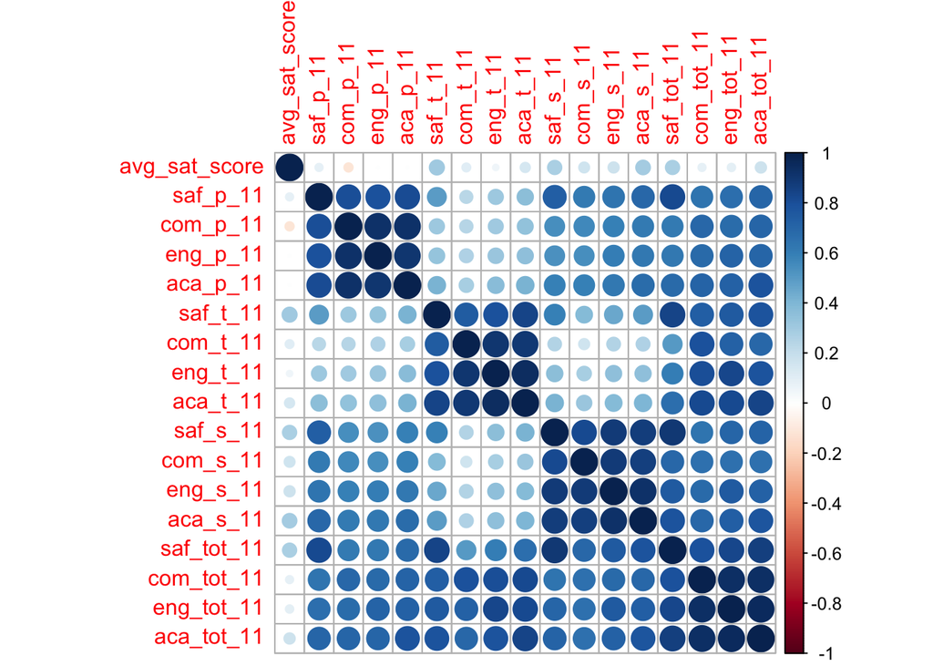

```r
# Filter the data down further. The use argument ensures that missing data is not included.
combined_survey %>%
  select(avg_sat_score, saf_p_11:aca_tot_11) %>%
  cor(use = "pairwise.complete.obs") %>%
  corrplot
```

In the above example. We first filtered the data by the columns we wanted, created a correlation matrix, then added this to `corrplot` to better visualize this. We ignored missing values. This shows us correlations between all variables, which isn’t really want we want. We’re only really interested in the first column in the above visualisation.

We could also do the same, but instead of visualizing, we could convert the matrix to a tibble, then filter the data down so that we only explore medium or strong relationships.

```r
# Create correlation matrix
correlations <- combined_survey %>%
  select(avg_sat_score, saf_p_11:aca_tot_11) %>%
  cor(use = "pairwise.complete.obs")

head(correlations, 4)
```

```
##               avg_sat_score   saf_p_11   com_p_11  eng_p_11    aca_p_11
## avg_sat_score    1.00000000 0.08913424 -0.1139639 0.0094307 0.008276863
## saf_p_11         0.08913424 1.00000000  0.8029932 0.7984741 0.817219807
## com_p_11        -0.11396394 0.80299315  1.0000000 0.9291268 0.925565838
## eng_p_11         0.00943070 0.79847408  0.9291268 1.0000000 0.907884041
##                saf_t_11  com_t_11   eng_t_11  aca_t_11  saf_s_11  com_s_11
## avg_sat_score 0.3091444 0.1074703 0.05612571 0.1411575 0.2772681 0.1623022
## saf_p_11      0.4904652 0.2316462 0.31403333 0.3642311 0.7324148 0.6169158
## com_p_11      0.3149366 0.2411942 0.30718612 0.3470251 0.5411576 0.5687691
## eng_p_11      0.3392305 0.2675333 0.32966966 0.3585188 0.5390565 0.5450478
##                eng_s_11  aca_s_11 saf_tot_11 com_tot_11 eng_tot_11 aca_tot_11
## avg_sat_score 0.1703460 0.2925880  0.2760410 0.08909856 0.09479407  0.1738004
## saf_p_11      0.6474957 0.6919735  0.8276467 0.64231997 0.66370163  0.7004380
## com_p_11      0.5913392 0.6146925  0.6105585 0.69339241 0.67145808  0.7028261
## eng_p_11      0.6075781 0.6236426  0.6209748 0.68203559 0.71010958  0.7054661
```

```r
class(correlations)
```

```
## [1] "matrix" "array"
```

So here we actually want to remove all columns except the first one. We can see that this is a matrix/array. Let’s first convert it to a tibble, and only keep the first column (and also the rownames)

```r
correlations <- correlations %>%
  as_tibble(rownames = "variable") %>%
  select(variable, avg_sat_score)

head(correlations, 4)
```

```
## # A tibble: 4 x 2
##   variable      avg_sat_score
##   <chr>                 <dbl>
## 1 avg_sat_score       1
## 2 saf_p_11            0.0891
## 3 com_p_11           -0.114
## 4 eng_p_11            0.00943
```

Next up, let’s filter the data to only show correlations that are over .25, or less than -.25.

```r
good_correlations <- correlations %>%
  filter(avg_sat_score > .25 | avg_sat_score < -.25)

good_correlations
```

```
## # A tibble: 5 x 2
##   variable      avg_sat_score
##   <chr>                 <dbl>
## 1 avg_sat_score         1
## 2 saf_t_11              0.309
## 3 saf_s_11              0.277
## 4 aca_s_11              0.293
## 5 saf_tot_11            0.276
```

Now that we’ve got the relationships we want to explore. Let’s create some scatterplots. Just so we’re clear, below are what these columns represent

aca_s_11 = Academic expectations score based on student responses saf_s_11 = Safety and Respect score based on student responses saf_t_11 = Safety and Respect score based on teacher responses saf_tot_11 = Safety and Respect total score

```r
selected_vars <- combined_survey %>%
  select(avg_sat_score, c(saf_t_11, saf_s_11, aca_s_11, saf_tot_11))

head(selected_vars, 4)
```

```
## # A tibble: 4 x 5
##   avg_sat_score saf_t_11 saf_s_11 aca_s_11 saf_tot_11
##           <dbl>    <dbl>    <dbl>    <dbl>      <dbl>
## 1          1122     NA       NA       NA         NA
## 2          1172      6.6      6        7          6.8
## 3          1149     NA       NA       NA         NA
## 4          1174      8.5      6.8      6.8        7.8
```

Let’s try reshape the data for practice, and to help us visualise the data.

aca_s_11 = Academic expectations score based on student responses saf_s_11 = Safety and Respect score based on student responses saf_t_11 = Safety and Respect score based on teacher responses saf_tot_11 = Safety and Respect total score

```r
# Pivoting data
selected_vars_reshaped <- selected_vars %>%
  pivot_longer(
    cols = c(saf_t_11, saf_s_11, aca_s_11, saf_tot_11),
    names_to = "Fields",
    values_to = "Values"
  ) %>%
  drop_na()

# Convert Fields to factors and rename to something more informative
selected_vars_reshaped$Fields <- as.factor(selected_vars_reshaped$Fields)
levels(selected_vars_reshaped$Fields) <- c("Academic Expectations - Student", "Safety & Respect - Student", "Safety & Respect - Teacher", "Safety & Respect - Total")

head(selected_vars_reshaped, 5)
```

```
## # A tibble: 5 x 3
##   avg_sat_score Fields                          Values
##           <dbl> <fct>                            <dbl>
## 1          1172 Safety & Respect - Teacher         6.6
## 2          1172 Safety & Respect - Student         6
## 3          1172 Academic Expectations - Student    7
## 4          1172 Safety & Respect - Total           6.8
## 5          1174 Safety & Respect - Teacher         8.5
```

Let’s now create some scatterplots with the transformed data. We’re going to use `facet_wrap` to create multiple scatterplots. This is why we transformed the data in the previous step.

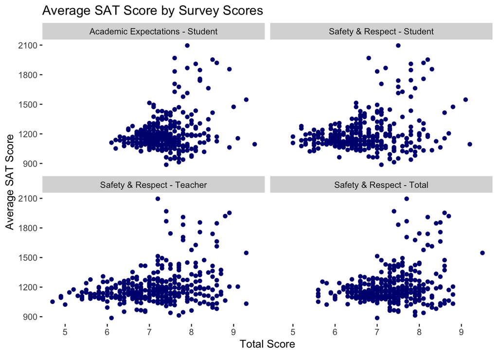

```r
# Scatterplots on the data
selected_vars_reshaped %>%
  ggplot(aes(x = Values, y = avg_sat_score)) +
  geom_point(color = "navy") +
  facet_wrap("Fields") +
  labs(
    x = "Total Score",
    y = "Average SAT Score",
    title = "Average SAT Score by Survey Scores"
  ) +
  theme(
    panel.background = element_rect("white")
  )
```

```r
# Correlations
c <- c(0.2925880, 0.2772681, 0.3091444, 0.2760410)
```

We can see that in schools where students have done very well on their SATs on average, these schools are generally considered safe and respectful by both teachers and students alike. Although we should note the relationships aren’t storng, and there are plenty schools that are ranked as safe and respectful which don’t hold a high average SAT score. It appears to be more the case that safety and respect are an important factor when it comes to students doing well.

Academic expectations of students also shares a relationship with average SAT scores. Now, possessing a high academic expectation may in fact help facilitate better grades. It might also be that these schools are generally considered very good schools. Inevitably students will have high expectations.

Let’s further transform our data. We’ll redo part of what we’ve done above, using `pivot_longer` as practice. We’ll also add a couple of other columns to make thing a bit clearer

```r
head(combined_survey)
```

```
## # A tibble: 6 x 61
##   DBN    school_name       `Num of SAT Test… `SAT Critical Rea… `SAT Math Avg. …
##   <chr>  <chr>                         <dbl>              <dbl>            <dbl>
## 1 01M292 HENRY STREET SCH…                29                355              404
## 2 01M448 UNIVERSITY NEIGH…                91                383              423
## 3 01M450 EAST SIDE COMMUN…                70                377              402
## 4 01M458 FORSYTH SATELLIT…                 7                414              401
## 5 01M509 MARTA VALLE HIGH…                44                390              433
## 6 01M515 LOWER EAST SIDE …               112                332              557
## # … with 56 more variables: SAT Writing Avg. Score <dbl>, avg_sat_score <dbl>,
## #   AP Test Takers <dbl>, Total Exams Taken <dbl>,
## #   Number of Exams with scores 3 4 or 5 <dbl>, exams_per_student <dbl>,
## #   high_score_percent <dbl>, avg_class_size <dbl>, frl_percent <dbl>,
## #   total_enrollment <dbl>, ell_percent <dbl>, sped_percent <dbl>,
## #   selfcontained_num <dbl>, asian_per <dbl>, black_per <dbl>,
## #   hispanic_per <dbl>, white_per <dbl>, male_per <dbl>, female_per <dbl>,
## #   Total Cohort <dbl>, grads_percent <dbl>, dropout_percent <dbl>, boro <chr>,
## #   lat <dbl>, long <dbl>, bn <chr>, schoolname <chr>, d75 <dbl>,
## #   studentssurveyed <chr>, highschool <dbl>, schooltype <chr>, rr_s <dbl>,
## #   rr_t <dbl>, rr_p <dbl>, N_s <dbl>, N_t <dbl>, N_p <dbl>, nr_s <dbl>,
## #   nr_t <dbl>, nr_p <dbl>, saf_p_11 <dbl>, com_p_11 <dbl>, eng_p_11 <dbl>,
## #   aca_p_11 <dbl>, saf_t_11 <dbl>, com_t_11 <dbl>, eng_t_11 <dbl>,
## #   aca_t_11 <dbl>, saf_s_11 <dbl>, com_s_11 <dbl>, eng_s_11 <dbl>,
## #   aca_s_11 <dbl>, saf_tot_11 <dbl>, com_tot_11 <dbl>, eng_tot_11 <dbl>,
## #   aca_tot_11 <dbl>
```

```r
# Pivot the data
combined_pivot <- combined_survey %>%
  pivot_longer(
    cols = c(saf_p_11:aca_tot_11),
    names_to = "survey_question",
    values_to = "score"
  )
```

We’ll now create a column for `response_type` and `metric`. For example, in **saf_s_11** the metric is **saf** and the response type is **student**

```r
combined_pivot <- combined_pivot %>%
  mutate(
    metric = str_sub(survey_question, 1, 3),
    response_type = str_sub(survey_question, 4, 6),
    response_type = case_when(
      response_type == "_s_" ~ "Student",
      response_type == "_t_" ~ "Teacher",
      response_type == "_p_" ~ "Parent",
      response_type == "_to" ~ "Total"
    ),
    metric = case_when(
      metric == "saf" ~ "Safety & Respect",
      metric == "com" ~ "Communication",
      metric == "eng" ~ "Engagement",
      metric == "aca" ~ "Academic Expectations"
    )
  ) %>%
  select(response_type, metric, score) %>%
  drop_na()

head(combined_pivot)
```

```
## # A tibble: 6 x 3
##   response_type metric                score
##   <chr>         <chr>                 <dbl>
## 1 Parent        Safety & Respect        7.9
## 2 Parent        Communication           7.4
## 3 Parent        Engagement              7.2
## 4 Parent        Academic Expectations   7.3
## 5 Teacher       Safety & Respect        6.6
## 6 Teacher       Communication           5.8
```

Let’s first summaries the data above, then create some visualisations

```r
group_summary <- combined_pivot %>%
  group_by(response_type, metric) %>%
  summarise(average_score = mean(score)) %>%
  arrange(response_type)
```

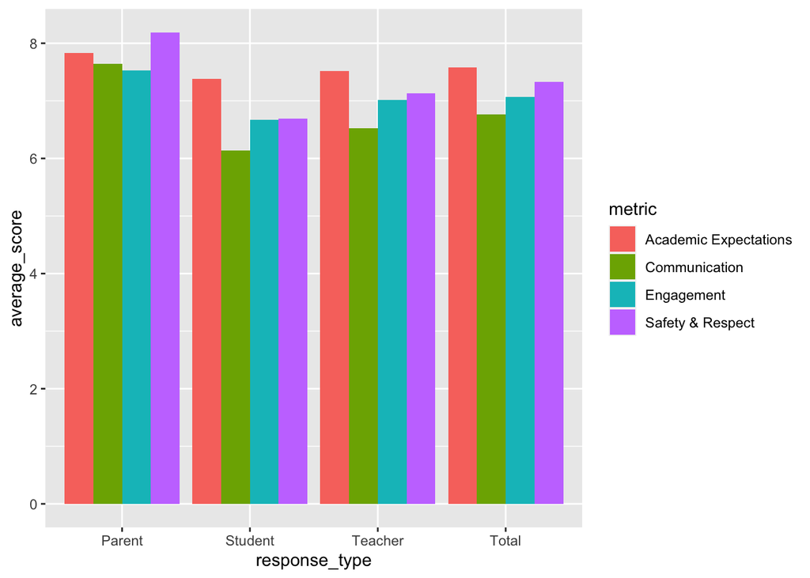

```r
group_summary %>%
  ggplot(aes(x = response_type, y = average_score, fill = metric)) +
  geom_bar(position="dodge", stat="identity")
```

Let’s create a boxplot instead:

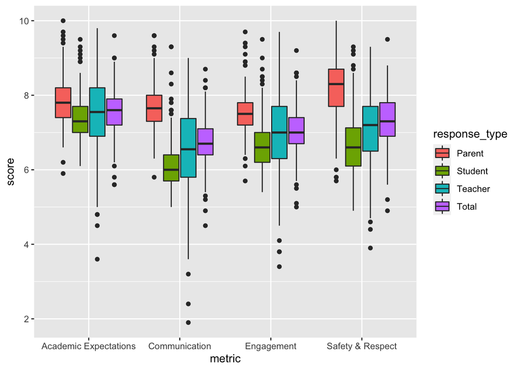

```r
combined_pivot %>%
  ggplot(aes(x= metric, y = score, fill = response_type)) +
  geom_boxplot()
```

We could note a few things here. Survey scores for parents were hightest for Safety & Respect questions. Survey scores for students and Teachers were lowest for Communication, with some low outliers here.

To be continued…